# Plots and Analysis

Andrew

7/20/2019

## Plots and Analysis

### CO2 (Station 1) vs Chlorophyl A

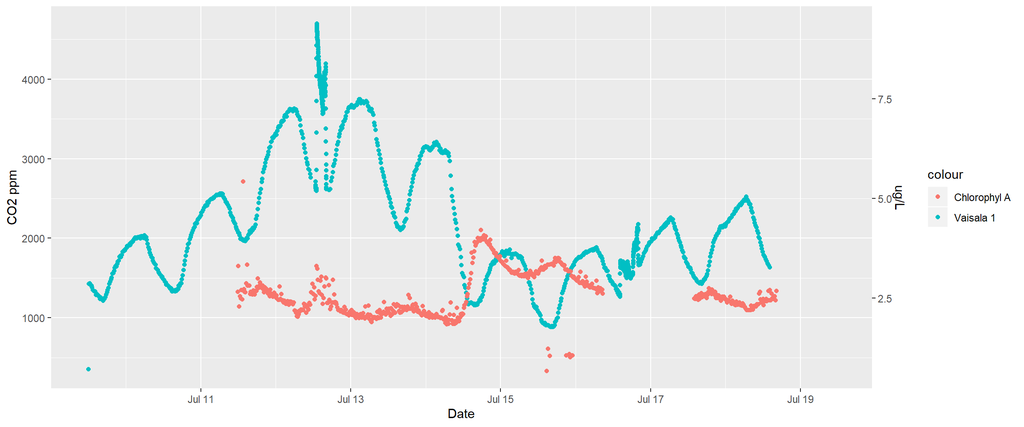

#### Notes

Chlorophyl A spikes starting on Sunday July 14 at ~10:45am and peaking at ~5:45pm that afternoon. This seems to be associated with the heavy rainfall that was experienced during that day. This also suggests that CO2 is undergoing dilution by the same rainfall. This may suggest that Chlorphyl A and CO2 have an inverse relationship.

### CO2 (Station 1) vs Phycocyanin

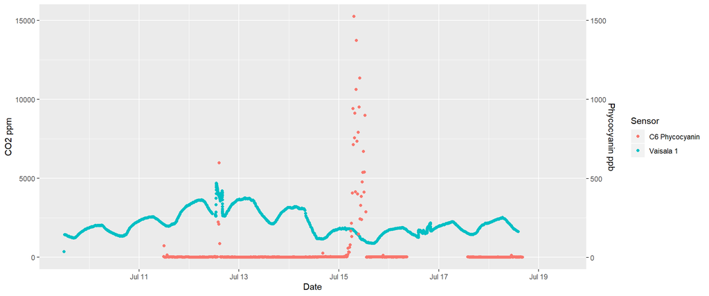

### Notes

Phycocyanin spikes hard beginning at 4:00 am on July 15 and peaking at 7:15am that same morning. It is unclear what may have caused this.

Filtering out this spike reveals this:

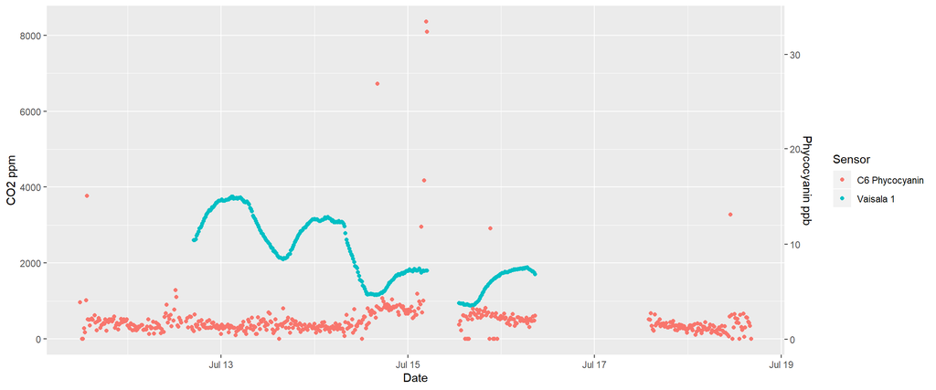

```r
phycoFilt <- data%>%
  filter(data$Phycocyanin_ppb < 50)

CO2vPhycoFilt <- ggplot(phycoFilt, aes(x = DateTime))+
  geom_point(aes(y = V1,colour = "Vaisala 1"))+
  geom_point(aes(y = Phycocyanin_ppb * 250, colour = "C6 Phycocyanin"))+
  scale_y_continuous(sec.axis = sec_axis(~./250, name = "Phycocyanin ppb"))+
  labs(x = "Date", y = "CO2 ppm", colour = "Sensor")

CO2vPhycoFilt
```

### CO2 vs. ppt

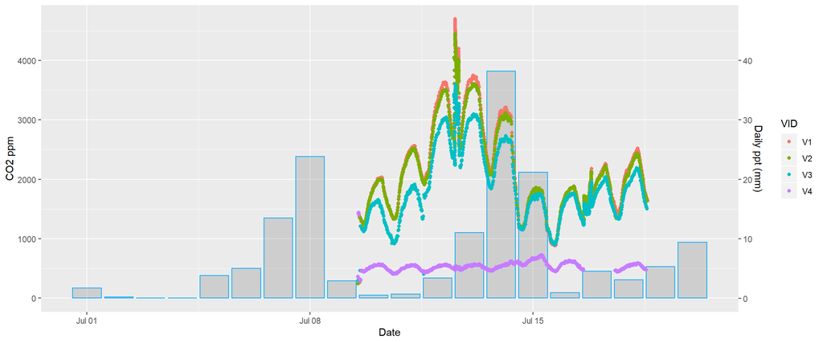

### Notes

There seems to be a strong inverse relationship between CO2 concentrations and rainfall. I imagine CO2 builds up under drier conditions and is flushed out with rainfall events.

### CO2 at Stations 1 & 2 vs. eosFD Flux between stations 1 and 2

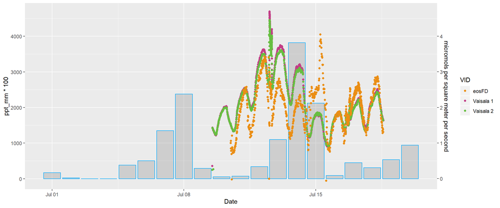

### Notes

This plot suggests an almost 1:1 relationship between flux and dissolved CO2. Flux is multiplied by 1,000 for the purposes of visualization